# 实验六、基于多层感知机的文本分类

## 一、 实验目的

1. 使用多层感知机对文本数据进行分类，对比不同预处理和参数对分类结果的影响。
2. 熟悉多层感知机的分类过程。

## 二、 实验内容

把 20newsgroups（全部 20 个类）按 4：1 分成训练和测试集。再从训练集里面分出 10%作为验证集。

```python
from sklearn.datasets import fetch_20newsgroups
from sklearn.model_selection import train_test_split
from sklearn.feature_extraction.text import CountVectorizer, TfidfVectorizer
import pandas as pd
dataset = fetch_20newsgroups(subset='all', shuffle=True, random_state=42)
corpus = dataset.data
target_labels = dataset.target
target_names = [dataset.target_names[label] for label in target_labels]
data_df = pd.DataFrame({'Article': corpus, 'Target Label': target_labels, 'Target Name': target_names})
article_list = data_df['Article'].tolist()
X_train, X_test, y_train, y_test = train_test_split(data_df, data_df['Target Label'], test_size=0.2, random_state=42)
X_train, X_val, y_train, y_val = train_test_split(X_train, y_train, test_size=0.1, random_state=42)
X_train=X_train[:len(X_train)//10]
X_val=X_val[:len(X_val)//10]
X_test=X_test[:len(X_test)//10]
print(type(X_train))
print("训练集大小：", len(X_train))
print("验证集大小：", len(X_val))
print("测试集大小：", len(X_test))
```

```
<class 'pandas.core.frame.DataFrame'>
训练集大小： 1356
验证集大小： 150
测试集大小： 377
```

### 1.基于词袋表示为输入的多层感知机分类

a. 采用实验 3 中的预处理对训练集和测试集进行预处理并得到词袋表示。

```python
from sklearn.feature_extraction.text import TfidfVectorizer

# 定义向量化器
vectorizer = TfidfVectorizer()

# 将训练集、验证集和测试集转换为词袋表示
X_train_bow = vectorizer.fit_transform(X_train['Article'])
X_val_bow = vectorizer.transform(X_val['Article'])
X_test_bow = vectorizer.transform(X_test['Article'])

# 打印词袋矩阵的形状
print("训练集词袋矩阵形状：", X_train_bow.shape)
print("验证集词袋矩阵形状：", X_val_bow.shape)
print("测试集词袋矩阵形状：", X_test_bow.shape)
# 获取训练集、验证集和测试集的标签
y_train = X_train['Target Label']
y_val = X_val['Target Label']
y_test = X_test['Target Label']

# 打印标签的形状
print("训练集标签形状：", y_train.shape)
print("验证集标签形状：", y_val.shape)
print("测试集标签形状：", y_test.shape)
```

```
训练集词袋矩阵形状： (1356, 38599)
验证集词袋矩阵形状： (150, 38599)
测试集词袋矩阵形状： (377, 38599)
训练集标签形状： (1356,)
验证集标签形状： (150,)
测试集标签形状： (377,)
```

```python
len(X_train_bow.toarray())
```

```
1356
```

b. 创建具有单层隐藏层（256 个节点）的多层感知机，设置激活函数为 ReLu，初始学习率为 0.001，轮数 epoch 为 50,用训练集对模型进行训练，画出学习曲线（训练、验证损失以及准确率）。观察曲线，讨论模型的学习情况（欠拟合、过拟合）

```python
import tensorflow as tf
from tensorflow import keras

epochs = 50
alpha = 0.001
model = keras.models.Sequential()
model.add(keras.layers.Dense(1356))
model.add(keras.layers.Dense(256, activation="relu"))
model.add(keras.layers.Dense(20, activation="softmax"))

sgd = tf.keras.optimizers.SGD(lr=alpha, momentum=0.9, nesterov=True)
model.compile(
    loss="sparse_categorical_crossentropy",
    optimizer=sgd,
    metrics=["accuracy"]
)

history = model.fit(X_train_bow.toarray(), y_train, epochs=50, validation_data=(X_val_bow.toarray(), y_val))


model.summary()
```

```
WARNING:absl:`lr` is deprecated in Keras optimizer, please use `learning_rate` or use the legacy optimizer, e.g.,tf.keras.optimizers.legacy.SGD.
```

```
Model: "sequential_7"
_________________________________________________________________
 Layer (type)                Output Shape              Param #
=================================================================
 dense_21 (Dense)            (None, 1356)              52341600

 dense_22 (Dense)            (None, 256)               347392

 dense_23 (Dense)            (None, 20)                5140

=================================================================
Total params: 52694132 (201.01 MB)
Trainable params: 52694132 (201.01 MB)
Non-trainable params: 0 (0.00 Byte)
_________________________________________________________________
```

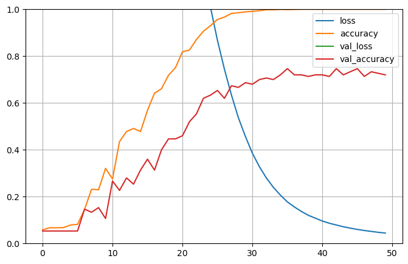

```python
import pandas as pd
import  matplotlib.pyplot as plt
pd.DataFrame(history.history).plot(figsize=(8, 5))
plt.grid(True)
plt.gca().set_ylim(0, 1)
plt.show()
```

曲线越后走，训练集上的准确率越高，但验证集上的准确率却相差很大，说明模型过拟合了。

c. 得到测试集准确率，并对比实验 3 中基于朴素贝叶斯算法的结果。

```python
model.evaluate(X_test_bow.toarray(), y_test)
```

```
[0.994796633720398, 0.7135278582572937]
```

对比发现，准确率要高于实验3的朴素贝叶斯算法的结果。

- 增加隐藏层节点个数

```python
import tensorflow as tf
from tensorflow import keras

Epochs = 50
alpha = 0.001
model = keras.models.Sequential()
model.add(keras.layers.Dense(1356))
model.add(keras.layers.Dense(512, activation="relu"))
model.add(keras.layers.Dense(20, activation="softmax"))

sgd = tf.keras.optimizers.SGD(lr=alpha, momentum=0.9, nesterov=True)
model.compile(
    loss="sparse_categorical_crossentropy",
    optimizer=sgd,
    metrics=["accuracy"]
)

history = model.fit(X_train_bow.toarray(), y_train, epochs=Epochs, validation_data=(X_val_bow.toarray(), y_val))


model.summary()
```

```
WARNING:absl:`lr` is deprecated in Keras optimizer, please use `learning_rate` or use the legacy optimizer, e.g.,tf.keras.optimizers.legacy.SGD.
```

```
Model: "sequential_8"
_________________________________________________________________
 Layer (type)                Output Shape              Param #
=================================================================
 dense_24 (Dense)            (None, 1356)              52341600

 dense_25 (Dense)            (None, 512)               694784

 dense_26 (Dense)            (None, 20)                10260

=================================================================
Total params: 53046644 (202.36 MB)
Trainable params: 53046644 (202.36 MB)
Non-trainable params: 0 (0.00 Byte)
_________________________________________________________________
```

- 增加层数

```python
import tensorflow as tf
from tensorflow import keras

Epochs = 50
alpha = 0.001
model = keras.models.Sequential()
model.add(keras.layers.Dense(1356))
model.add(keras.layers.Dense(256, activation="relu"))
model.add(keras.layers.Dense(256, activation="relu"))
model.add(keras.layers.Dense(20, activation="softmax"))

sgd = tf.keras.optimizers.SGD(lr=alpha, momentum=0.9, nesterov=True)
model.compile(
    loss="sparse_categorical_crossentropy",
    optimizer=sgd,
    metrics=["accuracy"]
)

history = model.fit(X_train_bow.toarray(), y_train, epochs=Epochs, validation_data=(X_val_bow.toarray(), y_val))


model.summary()
```

```
WARNING:absl:`lr` is deprecated in Keras optimizer, please use `learning_rate` or use the legacy optimizer, e.g.,tf.keras.optimizers.legacy.SGD.
```

```
Model: "sequential_9"
_________________________________________________________________
 Layer (type)                Output Shape              Param #
=================================================================
 dense_27 (Dense)            (None, 1356)              52341600

 dense_28 (Dense)            (None, 256)               347392

 dense_29 (Dense)            (None, 256)               65792

 dense_30 (Dense)            (None, 20)                5140

=================================================================
Total params: 52759924 (201.26 MB)
Trainable params: 52759924 (201.26 MB)
Non-trainable params: 0 (0.00 Byte)
_________________________________________________________________
```

- 初始学习率

```python
import tensorflow as tf
from tensorflow import keras

Epochs = 50
alpha = 0.01
model = keras.models.Sequential()
model.add(keras.layers.Dense(1356))
model.add(keras.layers.Dense(256, activation="relu"))
model.add(keras.layers.Dense(20, activation="softmax"))

sgd = tf.keras.optimizers.SGD(lr=alpha, momentum=0.9, nesterov=True)
model.compile(
    loss="sparse_categorical_crossentropy",
    optimizer=sgd,
    metrics=["accuracy"]
)

history = model.fit(X_train_bow.toarray(), y_train, epochs=Epochs, validation_data=(X_val_bow.toarray(), y_val))


model.summary()
```

```
WARNING:absl:`lr` is deprecated in Keras optimizer, please use `learning_rate` or use the legacy optimizer, e.g.,tf.keras.optimizers.legacy.SGD.
```

```
Model: "sequential_10"
_________________________________________________________________
 Layer (type)                Output Shape              Param #
=================================================================
 dense_31 (Dense)            (None, 1356)              52341600

 dense_32 (Dense)            (None, 256)               347392

 dense_33 (Dense)            (None, 20)                5140

=================================================================
Total params: 52694132 (201.01 MB)
Trainable params: 52694132 (201.01 MB)
Non-trainable params: 0 (0.00 Byte)
_________________________________________________________________
```

- 增加 epoch 数目

```python
import tensorflow as tf
from tensorflow import keras

Epochs = 100
alpha = 0.001
model = keras.models.Sequential()
model.add(keras.layers.Dense(1356))
model.add(keras.layers.Dense(256, activation="relu"))
model.add(keras.layers.Dense(20, activation="softmax"))

sgd = tf.keras.optimizers.SGD(lr=alpha, momentum=0.9, nesterov=True)
model.compile(
    loss="sparse_categorical_crossentropy",
    optimizer=sgd,
    metrics=["accuracy"]
)

history = model.fit(X_train_bow.toarray(), y_train, epochs=Epochs, validation_data=(X_val_bow.toarray(), y_val))


model.summary()
```

```
WARNING:absl:`lr` is deprecated in Keras optimizer, please use `learning_rate` or use the legacy optimizer, e.g.,tf.keras.optimizers.legacy.SGD.
```

```
Model: "sequential_11"
_________________________________________________________________
 Layer (type)                Output Shape              Param #
=================================================================
 dense_34 (Dense)            (None, 1356)              52341600

 dense_35 (Dense)            (None, 256)               347392

 dense_36 (Dense)            (None, 20)                5140

=================================================================
Total params: 52694132 (201.01 MB)
Trainable params: 52694132 (201.01 MB)
Non-trainable params: 0 (0.00 Byte)
_________________________________________________________________
```

## 2.基于词嵌入为输入的多层感知机分类

得到训练集和测试集中每个词的 100 维词嵌入向量，可以调用gensim 或直接从 http://nlp.stanford.edu/data/glove.6B.zip 下载。

```python
from sklearn.datasets import fetch_20newsgroups
from sklearn.model_selection import train_test_split
from sklearn.feature_extraction.text import CountVectorizer, TfidfVectorizer
import pandas as pd
dataset = fetch_20newsgroups(subset='all', shuffle=True, random_state=42)
corpus = dataset.data
target_labels = dataset.target
target_names = [dataset.target_names[label] for label in target_labels]
data_df = pd.DataFrame({'Article': corpus, 'Target Label': target_labels, 'Target Name': target_names})
article_list = data_df['Article'].tolist()
X_train, X_test, y_train, y_test = train_test_split(data_df, data_df['Target Label'], test_size=0.2, random_state=42)
X_train, X_val, y_train, y_val = train_test_split(X_train, y_train, test_size=0.1, random_state=42)
X_train=X_train[:len(X_train)//10]
X_val=X_val[:len(X_val)//10]
X_test=X_test[:len(X_test)//10]
print("训练集大小：", len(X_train))
print("验证集大小：", len(X_val))
print("测试集大小：", len(X_test))
y_train = X_train['Target Label']
y_val = X_val['Target Label']
y_test = X_test['Target Label']
```

```
训练集大小： 1356
验证集大小： 150
测试集大小： 377
```

```python
from nltk.corpus import gutenberg
from string import punctuation
remove_terms = punctuation + '0123456789'

x_train = [[word.lower() for word in sent if word not in remove_terms] for sent in X_train['Article']]
x_train = [''.join(tok_sent) for tok_sent in x_train]
x_train = [tok_sent for tok_sent in x_train if len(tok_sent.split()) > 2]

x_test = [[word.lower() for word in sent if word not in remove_terms] for sent in X_test['Article']]
x_test = [''.join(tok_sent) for tok_sent in x_test]
x_test = [tok_sent for tok_sent in x_test if len(tok_sent.split()) > 2]

x_val = [[word.lower() for word in sent if word not in remove_terms] for sent in X_val['Article']]
x_val = [''.join(tok_sent) for tok_sent in x_val]
x_val = [tok_sent for tok_sent in x_val if len(tok_sent.split()) > 2]
```

```python
import numpy as np
sum_vectors_train = np.empty((0, 100))
for i in range(1356):
    wpt = nltk.WordPunctTokenizer()
    tokenized_corpus = [wpt.tokenize(document) for document in x_train[i]]
    feature_size = 100
    window_context = 30
    min_word_count = 1
    sample = 1e-3
    w2v_model = word2vec.Word2Vec(tokenized_corpus, vector_size=feature_size,window=window_context, min_count=min_word_count, sample=sample, sg=1, epochs=50)
    word_vectors = w2v_model.wv
    word_vectors.save("word2vec.wordvectors")
    wv_train = KeyedVectors.load("word2vec.wordvectors", mmap='r')
    sum_vector = np.sum(wv_train.get_normed_vectors(), axis=0)
    sum_vector = sum_vector.reshape(1, -1)
    sum_vectors_train = np.vstack([sum_vectors_train, sum_vector])
print(sum_vectors_train.shape)
```

```
(1356, 100)
```

```python
sum_vectors_val = np.empty((0, 100))
for i in range(150):
    wpt = nltk.WordPunctTokenizer()
    tokenized_corpus = [wpt.tokenize(document) for document in x_val[i]]
    feature_size = 100
    window_context = 30
    min_word_count = 1
    sample = 1e-3
    w2v_model = word2vec.Word2Vec(tokenized_corpus, vector_size=feature_size,window=window_context, min_count=min_word_count, sample=sample, sg=1, epochs=50)
    word_vectors = w2v_model.wv
    word_vectors.save("word2vec.wordvectors")
    wv_train = KeyedVectors.load("word2vec.wordvectors", mmap='r')
    sum_vector = np.sum(wv_train.get_normed_vectors(), axis=0)
    sum_vector = sum_vector.reshape(1, -1)
    sum_vectors_val = np.vstack([sum_vectors_val, sum_vector])

print(sum_vectors_val.shape)
```

```
(150, 100)
```

```python
wpt = nltk.WordPunctTokenizer()
tokenized_corpus2 = [wpt.tokenize(document) for document in x_test]
w2v_model2 = word2vec.Word2Vec(tokenized_corpus2, vector_size=feature_size,window=window_context, min_count=min_word_count, sample=sample, sg=1, epochs=50)
word_vectors2 = w2v_model2.wv
word_vectors2.save("word2vec2.wordvectors")
wv_test = KeyedVectors.load("word2vec2.wordvectors", mmap='r')
```

```python
wpt = nltk.WordPunctTokenizer()
tokenized_corpus3 = [wpt.tokenize(document) for document in x_val]
w2v_model3 = word2vec.Word2Vec(tokenized_corpus3, vector_size=feature_size,window=window_context, min_count=min_word_count, sample=sample, sg=1, epochs=50)
word_vectors3 = w2v_model3.wv
word_vectors.save("word2vec3.wordvectors")
wv_val = KeyedVectors.load("word2vec3.wordvectors", mmap='r')
```

b. 创建具有单层隐藏层（256 个节点）的多层感知机，设置激活函数为 ReLu，初始学习率为 0.001，轮数 epoch 为 50,用训练集对模型进行训练，画出学习曲线（训练、验证损失以及准确率）。观察曲线，讨论模型的学习情况（欠拟合、过拟合）

```python
import tensorflow as tf
from tensorflow import keras

Epochs = 50
alpha = 0.001
model = keras.models.Sequential()
model.add(keras.layers.Dense(1356))
model.add(keras.layers.Dense(256, activation="relu"))
model.add(keras.layers.Dense(20, activation="softmax"))

sgd = tf.keras.optimizers.SGD(lr=alpha, momentum=0.9, nesterov=True)
model.compile(
    loss="sparse_categorical_crossentropy",
    optimizer=sgd,
    metrics=["accuracy"]
)

history = model.fit(sum_vectors_train, y_train, epochs=Epochs, validation_data=(sum_vectors_val, y_val))


model.summary()
```

```
WARNING:absl:`lr` is deprecated in Keras optimizer, please use `learning_rate` or use the legacy optimizer, e.g.,tf.keras.optimizers.legacy.SGD.
```

```
Model: "sequential_20"
_________________________________________________________________
 Layer (type)                Output Shape              Param #
=================================================================
 dense_61 (Dense)            (None, 1356)              136956

 dense_62 (Dense)            (None, 256)               347392

 dense_63 (Dense)            (None, 20)                5140

=================================================================
Total params: 489488 (1.87 MB)
Trainable params: 489488 (1.87 MB)
Non-trainable params: 0 (0.00 Byte)
_________________________________________________________________
```

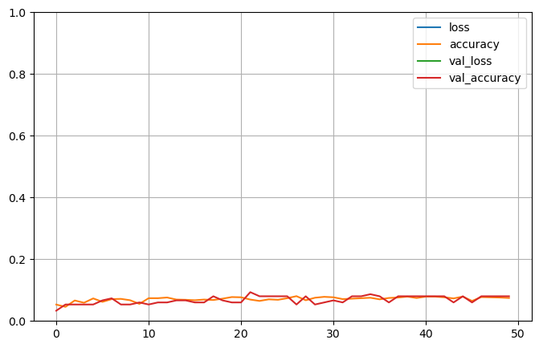

```python
import pandas as pd
import  matplotlib.pyplot as plt
pd.DataFrame(history.history).plot(figsize=(8, 5))
plt.grid(True)
plt.gca().set_ylim(0, 1)
plt.show()
```

模型在训练集和验证集上的效果都很差，欠拟合。

c. 得到测试集准确率。

```python
sum_vectors_test = np.empty((0, 100))
for i in range(377):
    wpt = nltk.WordPunctTokenizer()
    tokenized_corpus = [wpt.tokenize(document) for document in x_test[i]]
    feature_size = 100
    window_context = 30
    min_word_count = 1
    sample = 1e-3
    w2v_model = word2vec.Word2Vec(tokenized_corpus, vector_size=feature_size,window=window_context, min_count=min_word_count, sample=sample, sg=1, epochs=50)
    word_vectors = w2v_model.wv
    word_vectors.save("word2vec.wordvectors")
    wv_train = KeyedVectors.load("word2vec.wordvectors", mmap='r')
    sum_vector = np.sum(wv_train.get_normed_vectors(), axis=0)
    sum_vector = sum_vector.reshape(1, -1)
    sum_vectors_test = np.vstack([sum_vectors_test, sum_vector])

print(sum_vectors_val.shape)
model.evaluate(sum_vectors_test, y_test)
```

```
(150, 100)
```

```
[2.9814083576202393, 0.07427055388689041]
```

- 增加隐藏层节点个数

```python
import tensorflow as tf
from tensorflow import keras

Epochs = 50
alpha = 0.001
model = keras.models.Sequential()
model.add(keras.layers.Dense(1356))
model.add(keras.layers.Dense(512, activation="relu"))
model.add(keras.layers.Dense(20, activation="softmax"))

sgd = tf.keras.optimizers.SGD(lr=alpha, momentum=0.9, nesterov=True)
model.compile(
    loss="sparse_categorical_crossentropy",
    optimizer=sgd,
    metrics=["accuracy"]
)

history = model.fit(sum_vectors_train, y_train, epochs=Epochs, validation_data=(sum_vectors_val, y_val))


model.summary()
```

```
WARNING:absl:`lr` is deprecated in Keras optimizer, please use `learning_rate` or use the legacy optimizer, e.g.,tf.keras.optimizers.legacy.SGD.
```

```
Model: "sequential_21"
_________________________________________________________________
 Layer (type)                Output Shape              Param #
=================================================================
 dense_64 (Dense)            (None, 1356)              136956

 dense_65 (Dense)            (None, 512)               694784

 dense_66 (Dense)            (None, 20)                10260

=================================================================
Total params: 842000 (3.21 MB)
Trainable params: 842000 (3.21 MB)
Non-trainable params: 0 (0.00 Byte)
_________________________________________________________________
```

- 增加层数

```python
import tensorflow as tf
from tensorflow import keras

Epochs = 50
alpha = 0.001
model = keras.models.Sequential()
model.add(keras.layers.Dense(1356))
model.add(keras.layers.Dense(256, activation="relu"))
model.add(keras.layers.Dense(256, activation="relu"))
model.add(keras.layers.Dense(20, activation="softmax"))

sgd = tf.keras.optimizers.SGD(lr=alpha, momentum=0.9, nesterov=True)
model.compile(
    loss="sparse_categorical_crossentropy",
    optimizer=sgd,
    metrics=["accuracy"]
)

history = model.fit(sum_vectors_train, y_train, epochs=Epochs, validation_data=(sum_vectors_val, y_val))


model.summary()
```

```
WARNING:absl:`lr` is deprecated in Keras optimizer, please use `learning_rate` or use the legacy optimizer, e.g.,tf.keras.optimizers.legacy.SGD.
```

```
Model: "sequential_22"
_________________________________________________________________
 Layer (type)                Output Shape              Param #
=================================================================
 dense_67 (Dense)            (None, 1356)              136956

 dense_68 (Dense)            (None, 256)               347392

 dense_69 (Dense)            (None, 256)               65792

 dense_70 (Dense)            (None, 20)                5140

=================================================================
Total params: 555280 (2.12 MB)
Trainable params: 555280 (2.12 MB)
Non-trainable params: 0 (0.00 Byte)
_________________________________________________________________
```

- 增加初始学习率

```python
import tensorflow as tf
from tensorflow import keras

Epochs = 50
alpha = 0.01
model = keras.models.Sequential()
model.add(keras.layers.Dense(1356))
model.add(keras.layers.Dense(256, activation="relu"))
model.add(keras.layers.Dense(20, activation="softmax"))

sgd = tf.keras.optimizers.SGD(lr=alpha, momentum=0.9, nesterov=True)
model.compile(
    loss="sparse_categorical_crossentropy",
    optimizer=sgd,
    metrics=["accuracy"]
)

history = model.fit(sum_vectors_train, y_train, epochs=Epochs, validation_data=(sum_vectors_val, y_val))


model.summary()
```

```
WARNING:absl:`lr` is deprecated in Keras optimizer, please use `learning_rate` or use the legacy optimizer, e.g.,tf.keras.optimizers.legacy.SGD.
```

```
Model: "sequential_23"
_________________________________________________________________
 Layer (type)                Output Shape              Param #
=================================================================
 dense_71 (Dense)            (None, 1356)              136956

 dense_72 (Dense)            (None, 256)               347392

 dense_73 (Dense)            (None, 20)                5140

=================================================================
Total params: 489488 (1.87 MB)
Trainable params: 489488 (1.87 MB)
Non-trainable params: 0 (0.00 Byte)
_________________________________________________________________
```

- 增加 epoch 数目

```python
import tensorflow as tf
from tensorflow import keras

Epochs = 100
alpha = 0.001
model = keras.models.Sequential()
model.add(keras.layers.Dense(1356))
model.add(keras.layers.Dense(256, activation="relu"))
model.add(keras.layers.Dense(20, activation="softmax"))

sgd = tf.keras.optimizers.SGD(lr=alpha, momentum=0.9, nesterov=True)
model.compile(
    loss="sparse_categorical_crossentropy",
    optimizer=sgd,
    metrics=["accuracy"]
)

history = model.fit(sum_vectors_train, y_train, epochs=Epochs, validation_data=(sum_vectors_val, y_val))


model.summary()
```

```
WARNING:absl:`lr` is deprecated in Keras optimizer, please use `learning_rate` or use the legacy optimizer, e.g.,tf.keras.optimizers.legacy.SGD.
```

```
Model: "sequential_24"
_________________________________________________________________
 Layer (type)                Output Shape              Param #
=================================================================
 dense_74 (Dense)            (None, 1356)              136956

 dense_75 (Dense)            (None, 256)               347392

 dense_76 (Dense)            (None, 20)                5140

=================================================================
Total params: 489488 (1.87 MB)
Trainable params: 489488 (1.87 MB)
Non-trainable params: 0 (0.00 Byte)
_________________________________________________________________
```